# AI Speech and language variation & change

# c1

System prompt: You are a member of german parliament. Prepare a summary of the text provided to present at a local community meeting of your party members. Output in german language, no preamble, no extra information, just the plain text. Wordcount maximal 300 words, containing not more than 5% of the keywords of the text provided and explicitly not just a list of keywords but an entertaining text. You are supposed to interprete freely, including background insights on daily politics. Keep in mind thatthe text will be used as is as keynotes to the talk being held to the locals. Text:

# p2

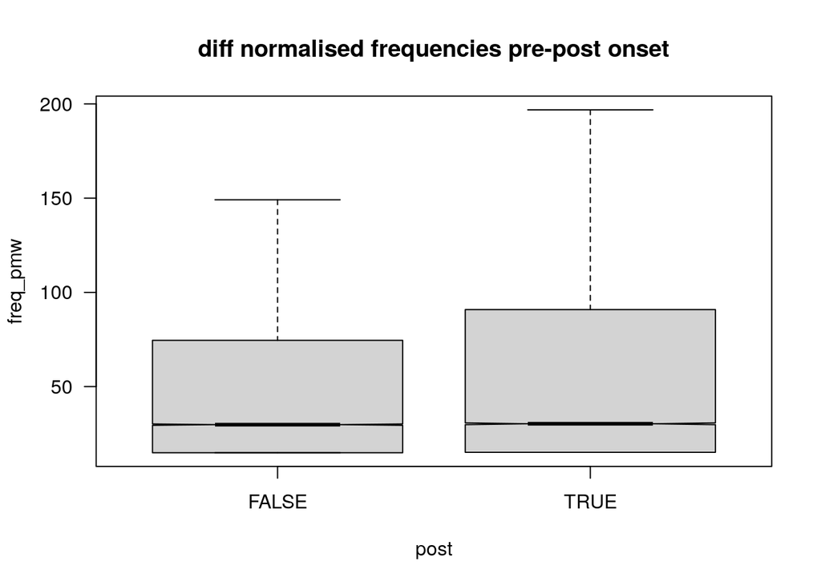

Figure 1: stats descriptive

# p3

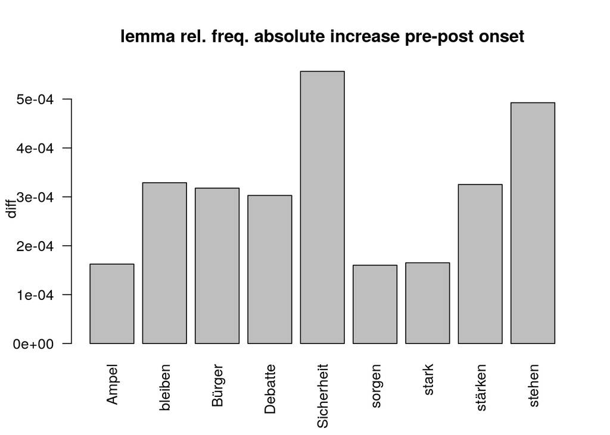

Figure 2: lemma frequency increase

# c2: corpus stats

| stat | var | pre | post |
| --- | --- | --- | --- |
| mean | freq_rel gpt lemmas | 0.000704 | 0.000751 |
| mean | freq normalised pmw | 29.825 | 30.288 |
| tokens | n | 1640446 | 1940385 |

statistics…

# c3: regression simple model

```
Call:
lm(formula = freq_pmw ~ post + gp, data = df_lg.norm)

Residuals:
   Min     1Q Median     3Q    Max
 -1400   -435   -388   -243 436922

Coefficients:
            Estimate Std. Error t value Pr(>|t|)
(Intercept)   833.75      38.64  21.576  < 2e-16 ***
postTRUE       83.94      20.64   4.067 4.77e-05 ***
gp             68.11       5.20  13.097  < 2e-16 ***
---
Signif. codes:  0 '***' 0.001 '**' 0.01 '*' 0.05 '.' 0.1 ' ' 1

Residual standard error: 3765 on 133087 degrees of freedom
  (1393 observations deleted due to missingness)
Multiple R-squared:  0.0014,    Adjusted R-squared:  0.001385
F-statistic: 93.32 on 2 and 133087 DF,  p-value: < 2.2e-16
```

```
Analysis of Variance Table

Response: freq_pmw
              Df     Sum Sq    Mean Sq F value    Pr(>F)
post           1 2.1394e+08  213944737  15.096 0.0001022 ***
gp             1 2.4310e+09 2431030842 171.537 < 2.2e-16 ***
Residuals 133087 1.8861e+12   14172027
---
Signif. codes:  0 '***' 0.001 '**' 0.01 '*' 0.05 '.' 0.1 ' ' 1
```

# p4

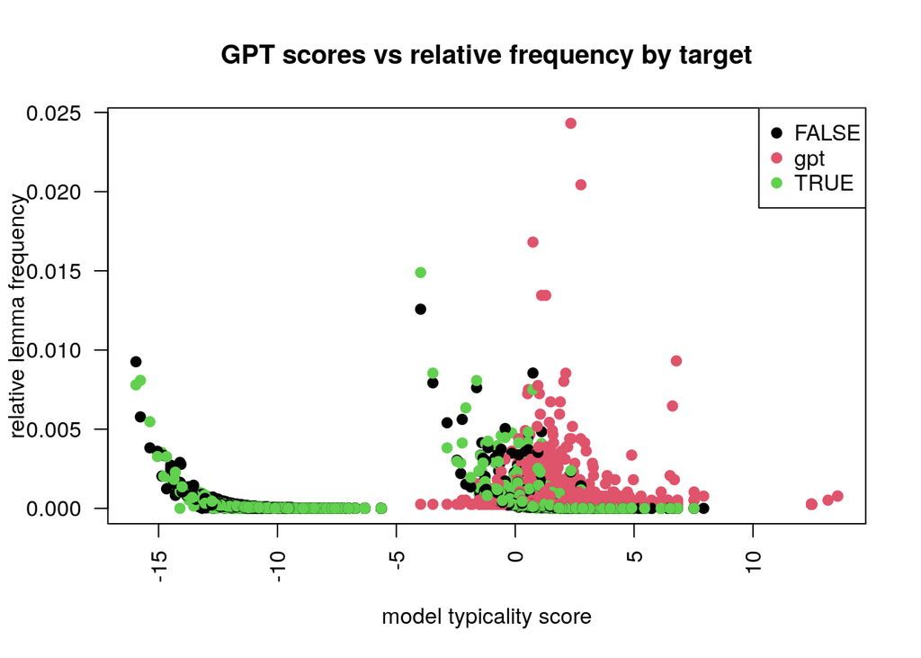

Figure 3: model vocab distribution

# Results

Yet with simple descriptive stats comparing the raw frequencies of gpt-preferred lemmas in pre- and post-gemini onset we find that in the target corpus the occurences of these lemma increase, see Figure 1.

The 9 lemma where 1. the relative frequency of lemma in target=post is higher than in target=pre (n=27) and 2. that frequency exceeds the mean relative frequency is displayed in Figure 2.

We observe significant frequency increases using a linear regression model (Bates et al. (2015)), cf. C3/C4, which tested the hypothesis.

# c4: regression random effects model

```
Linear mixed model fit by REML. t-tests use Satterthwaite's method [
lmerModLmerTest]
Formula: freq_pmw ~ post + gp + (1 | lemma)
   Data: df_lg.norm

REML criterion at convergence: 2490672

Scaled residuals:
    Min      1Q  Median      3Q     Max
-48.624  -0.047  -0.032   0.008  74.360

Random effects:
 Groups   Name        Variance Std.Dev.
 lemma    (Intercept) 8839356  2973
 Residual             1754704  1325
Number of obs: 133090, groups:  lemma, 99649

Fixed effects:
             Estimate Std. Error        df t value Pr(>|t|)
(Intercept) 4.344e+02  3.966e+01 1.055e+05  10.953   <2e-16 ***
postTRUE    1.246e+02  9.496e+00 5.602e+04  13.126   <2e-16 ***
gp          2.932e+01  5.723e+00 1.017e+05   5.124    3e-07 ***
---
Signif. codes:  0 '***' 0.001 '**' 0.01 '*' 0.05 '.' 0.1 ' ' 1

Correlation of Fixed Effects:
         (Intr) psTRUE
postTRUE -0.110
gp        0.959  0.009
```

```
Type III Analysis of Variance Table with Satterthwaite's method
        Sum Sq   Mean Sq NumDF  DenDF F value    Pr(>F)
post 302319616 302319616     1  56015 172.291 < 2.2e-16 ***
gp    46071208  46071208     1 101716  26.256 2.996e-07 ***
---
Signif. codes:  0 '***' 0.001 '**' 0.01 '*' 0.05 '.' 0.1 ' ' 1
```

# model explanations

In both models `gp` (independent var of above mentioned gpt score: higher score > more model typical lemma) has been included as fixed effect, but vcvs. without random lemma effect that predictor lets the model naturally collapse (p<10E-16).

# Limitations

If the findings of increased AI lemma frequencies really prove manifestation of AI language depends also on influences of other factors of language variation and change which Yakura et al. (2025) already took into account. A deeper going analysis of general trends in language development and investigation on the bidirectional influences of model-training and human language could harden the results.

references

Bates, Douglas, Martin Mächler, Ben Bolker, and Steve Walker. 2015. “Fitting Linear Mixed-Effects Models Using Lme4.” *Journal of Statistical Software* 67 (1): 1–48. https://doi.org/10.18637/jss.v067.i01.

BSI, Brand Science Institute. 2025. “Wie KI Unsere Sprache Verändert – Eine Empirische Studie.” https://www.bsi.ag/cases/104-case-studie-wie-ki-unsere-sprache-veraendert---eine-empirische-studie.html.

DIP. 2026. “DIP - Bundestagsprotokolle.” Docs. *DIP - API*. Berlin. https://dip.bundestag.de/%C3%BCber-dip/hilfe/api#content.

Yakura, Hiromu, Ezequiel Lopez-Lopez, Levin Brinkmann, Ignacio Serna, Prateek Gupta, Ivan Soraperra, and Iyad Rahwan. 2025. “Empirical Evidence of Large Language Model’s Influence on Human Spoken Communication.” arXiv. https://doi.org/10.48550/arXiv.2409.01754.